# 0 SRC

Dr. Victor Augusto Lizcano S.

2023-11-30

## **Sistemas de referencia de coordenadas (SRC)**

Un sistema de referencia de coordenadas (Coordinate Reference System, CRS) es un marco utilizado para medir la posición de cualquier objeto (real o imaginario) sobre la superficie de la Tierra mediante el uso de las coordenadas (aplicadas a una superficie esférica o elipsiodal, o a una superficie plana). En el caso de las superficies planas, esta emplean proyecciones cartográficas intenta transformar la tierra de su forma esférica (3D) (SRC grográficas) a una forma plana (2D) (SRC proyectadas).

### **Familia de proyecciones cartográficas**

Algunas formas de proyectar la superficie del planeta Tierra son: (a) superficies cilindricas; (b) superficies cónicas; o (c) superficies planas. A este conjunto de proyeccciones se le denomina proyecciones cartográficas.

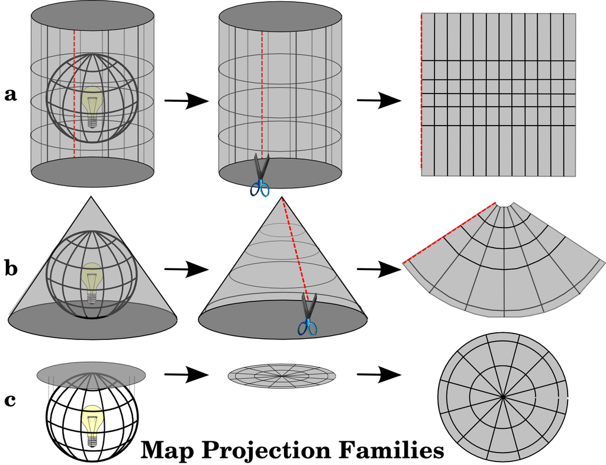

Familias de proyecciones cartográficas

### **Tipos de SRC**

Existen dos tipos diferentes de sistemas de referencia de coordenadas:

Sistemas de coordenadas geográficas: Estos sistemas utilizan la latitud y la longitud para definir las ubicaciones en la tierra. Un ejemplo común es el sistema de coordenadas geográficas WGS84 utilizado por el Sistema de Posicionamiento Global (GPS).

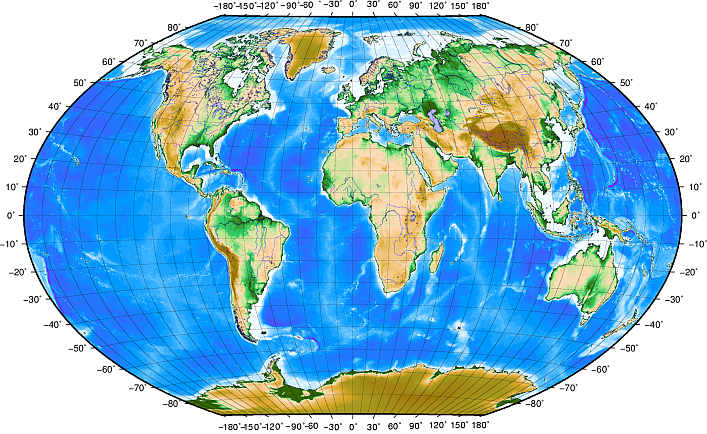

WGS 84

Sistemas de coordenadas proyectadas: Estos sistemas proyectan la tierra, que es tridimensional, en un plano bidimensional (2D). Esto permite medir distancias y áreas. Un ejemplo común es el sistema de coordenadas Universal Transverse Mercator (UTM).

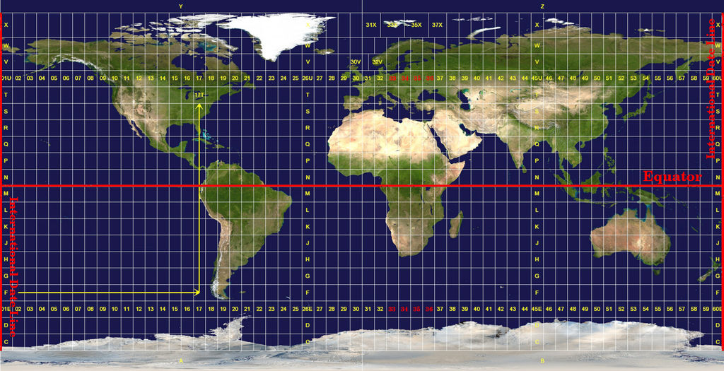

UTM

### **Diferencia entre Datum y SRC**

El datum se utiliza para definir la forma (una esfera, un elipsoide o un geoide) y la orientación de la Tierra, y se basa en una serie de puntos de referencia que se utilizan para medir la latitud, la longitud y la altitud. Estos puntos de referencia pueden ser físicos, como montañas o ríos, o pueden ser puntos imaginarios que se han definido matemáticamente. En cambio el SRC se utiliza para representar la ubicación de los objetos en la Tierra, ya sea en coordenadas geográficas o proyectadas.